```python
import os
import numpy as np
import matplotlib
from matplotlib import pyplot as plt
from tqdm import tqdm

import torch
import torch.nn as nn
import torchvision.transforms as transforms
import torchvision.datasets as datasets

plt.style.use('seaborn')
import seaborn as sns
sns.set_style("whitegrid", {'axes.grid' : False})

import data_loaders as dl
from models import CIFAR10_MLP_Classifier, CIFAR10_CNN_Classifier
import helpers
import evaluations
import trainings

device = torch.device("cuda" if torch.cuda.is_available() else "cpu")
```

# Assignment 2

## Task 1.

- Train and compare the MLP from Assignment 1 and a simple CNN on the CIFAR-10 dataset (available in PyTorch) with somewhat optimized hyper-parameters

### Let's download Cifar10 Dataset

Code of loaders is in data_loaders.py

```python
train_loader, eval_loader = dl.load_train_data('cifar10', 128)
```

```
Files already downloaded and verified
Files already downloaded and verified
```

Add a human-readable description of dataset classes

```python
classes = ('plane', 'car', 'bird', 'cat', 'deer',
           'dog', 'frog', 'horse', 'ship', 'truck')
```

Let's look at some random samples

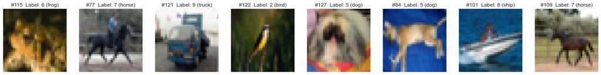

```python
train_batch = next(iter(train_loader))
sample_imgs, sample_labels = train_batch


N_IMGS = 8
fig, ax = plt.subplots(1,N_IMGS)
fig.set_size_inches(3 * N_IMGS, 3)

ids = np.random.randint(low=0, high=len(sample_imgs), size=N_IMGS)

for i, n in enumerate(ids):
    img = sample_imgs[n]

    # because of normalization of dataset images have strange range, let's fix it with normalization to range [0, 1] for adequate visualization
    img = img.clone().detach()
    img += np.abs(img.min())
    img /= img.max()

    label = sample_labels[n]
    ax[i].imshow(img.permute(1,2,0))
    ax[i].set_title(f"#{n}  Label: {label} ({classes[label]})")
    ax[i].axis("off")
plt.show()
```

```python
def count_model_params(model):
    """ Counting the number of learnable parameters in a nn.Module """
    num_params = sum(p.numel() for p in model.parameters() if p.requires_grad)
    return num_params
```

Let's create Model for classification of Cifar10 dataset.  
Code of model is in models.py

```python
mlp_model = CIFAR10_MLP_Classifier(num_neurons=[512, 256, 32]).to(device)
print(mlp_model)
print(f"Number of parameters: {count_model_params(mlp_model)}")
```

```
CIFAR10_MLP_Classifier(
  (layers): ModuleList(
    (0): Flatten(start_dim=1, end_dim=-1)
    (1): Linear(in_features=3072, out_features=512, bias=True)
    (2): ReLU()
    (3): Linear(in_features=512, out_features=256, bias=True)
    (4): ReLU()
    (5): Linear(in_features=256, out_features=32, bias=True)
    (6): ReLU()
    (7): Linear(in_features=32, out_features=10, bias=True)
  )
)
Number of parameters: 1713258
```

### Let's train MLP Model

```python
NUM_EPOCHS = 24
LR = 0.001
```

```python
criterion_mlp = nn.CrossEntropyLoss()  # already includes a Softmax!
optimizer_mlp = torch.optim.Adam(mlp_model.parameters(), lr=LR)
```

```python
loss_list_mlp = []
acc_list_mlp = []

for epoch in range(NUM_EPOCHS):
    progress_bar = tqdm(train_loader, total=len(train_loader))
    for i, (imgs, labels) in enumerate(progress_bar):
        # using GPU
        imgs, labels = imgs.to(device), labels.to(device)

        # forward pass
        flattened_imgs = imgs.flatten(start_dim=1)
        preds = mlp_model(flattened_imgs)

        # computing error
        loss = criterion_mlp(preds, labels)
        loss_list_mlp.append(loss.item())

        # computing accuracy
        train_acc = (preds.argmax(dim=1) == labels).float().mean()
        acc_list_mlp.append(train_acc.item())

        # removing accumulated gradients
        optimizer_mlp.zero_grad()

        # backprogating error to compute gradients
        loss.backward()

        # updating arameters
        optimizer_mlp.step()

        if(i % 100 == 0 or i == len(train_loader) - 1):
            progress_bar.set_description(f"Epoch {epoch + 1} Iter {i + 1}: loss {loss.item():.5f}. ")
```

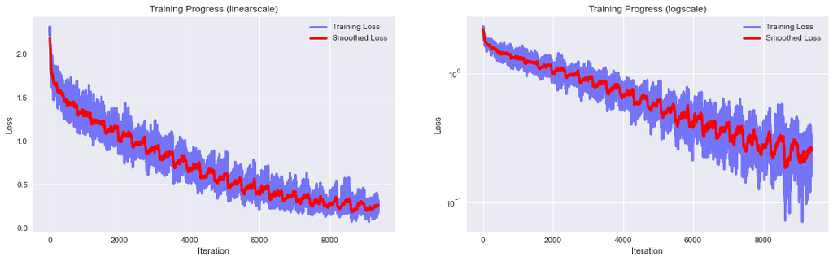

```python
helpers.plot_values_linear_n_log(loss_list_mlp, mode="Loss")
```

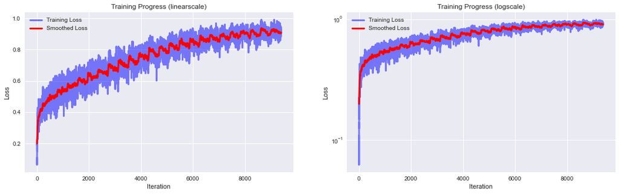

```python
helpers.plot_values_linear_n_log(acc_list_mlp, mode="Loss")
```

```python
acc_mlp, y_true_mlp, y_pred_mlp, eval_loss_list_mlp = evaluations.evaluate_model(mlp_model, criterion_mlp, eval_loader, device)
```

```
Test accuracy: 53.82%
```

Let's create CNN Model

```python
cnn_model = CIFAR10_CNN_Classifier().to(device)

print(cnn_model)
```

```
CIFAR10_CNN_Classifier(
  (network): Sequential(
    (0): Conv2d(3, 32, kernel_size=(3, 3), stride=(1, 1), padding=(1, 1))
    (1): ReLU()
    (2): Conv2d(32, 32, kernel_size=(3, 3), stride=(1, 1), padding=(1, 1))
    (3): ReLU()
    (4): MaxPool2d(kernel_size=2, stride=2, padding=0, dilation=1, ceil_mode=False)
    (5): Conv2d(32, 64, kernel_size=(3, 3), stride=(1, 1), padding=(1, 1))
    (6): ReLU()
    (7): Conv2d(64, 64, kernel_size=(3, 3), stride=(1, 1), padding=(1, 1))
    (8): ReLU()
    (9): MaxPool2d(kernel_size=2, stride=2, padding=0, dilation=1, ceil_mode=False)
    (10): Flatten(start_dim=1, end_dim=-1)
    (11): Linear(in_features=4096, out_features=100, bias=True)
    (12): ReLU()
    (13): Linear(in_features=100, out_features=10, bias=True)
  )
)
```

```python
criterion_cnn = nn.CrossEntropyLoss()
optimizer_cnn = torch.optim.Adam(cnn_model.parameters(), lr = LR)
```

```python
loss_list_cnn, acc_list_cnn, loss_epoch_list_cnn, acc_epoch_list_cnn, loss_epoch_list_eval_cnn, acc_epoch_list_eval_cnn = \
    trainings.train(cnn_model, criterion_cnn, train_loader, eval_loader,  optimizer_cnn, NUM_EPOCHS, device)
```

```
Test accuracy: 58.5%
```

```
Test accuracy: 64.96%
```

```
Test accuracy: 69.78%
```

```
Test accuracy: 72.75%
```

```
Test accuracy: 73.17%
```

```
Test accuracy: 74.32%
```

```
Test accuracy: 74.07%
```

```
Test accuracy: 74.38%
```

```
Test accuracy: 74.5%
```

```
Test accuracy: 74.4%
```

```
Test accuracy: 73.52%
```

```
Test accuracy: 73.74%
```

```
Test accuracy: 73.56%
```

```
Test accuracy: 73.75%
```

```
Test accuracy: 73.08%
```

```
Test accuracy: 73.61%
```

```
Test accuracy: 73.24%
```

```
Test accuracy: 73.44%
```

```
Test accuracy: 72.21%
```

```
Test accuracy: 73.14%
```

```
Test accuracy: 73.1%
```

```
Test accuracy: 73.48%
```

```
Test accuracy: 73.25%
```

```
Test accuracy: 73.07%
```

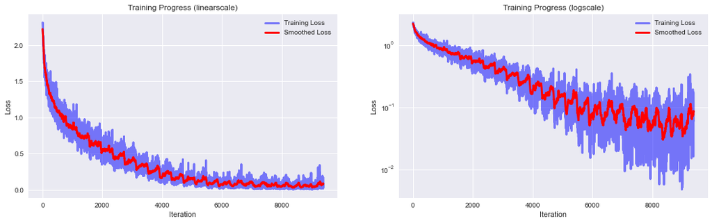

```python
helpers.plot_values_linear_n_log(loss_list_cnn, mode="Loss")
```

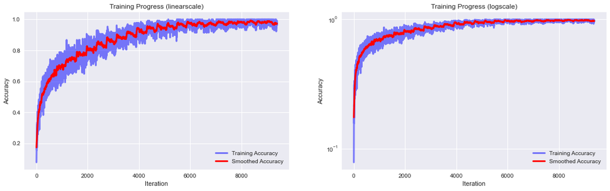

```python
helpers.plot_values_linear_n_log(acc_list_cnn, mode="Accuracy")
```

```python
acc_cnn, y_true_cnn, y_pred_cnn, eval_loss_list_cnn = evaluations.evaluate_model(cnn_model, criterion_cnn, eval_loader, device)
```

```
Test accuracy: 73.07%
```

```python
def plot_train_n_eval_metric(train_list, eval_list, mode: str="Loss"):
    assert len(train_list) == len(eval_list)
    x = np.arange(0, len(train_list))
    # plot training and validation loss/accuracy
    plt.plot(x, train_list, label = f"Training {mode}")
    plt.plot(x, eval_list, label = f"Evaluation {mode}")

    plt.legend()
    plt.show()
```

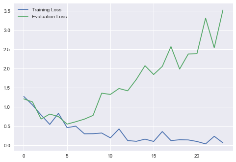

```python
plot_train_n_eval_metric(loss_epoch_list_cnn, loss_epoch_list_eval_cnn, mode="Loss")
```

Our CNN model definitely has some problems with overfitting

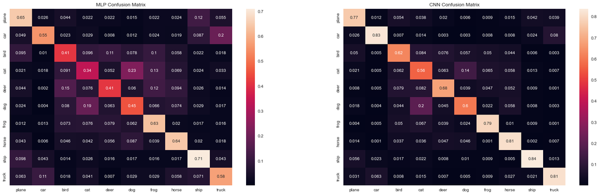

```python
# TODO compare confusion matrices of CNN and MLP


helpers.plot_2_confusion_m(y_true_mlp, y_pred_mlp, y_true_cnn, y_pred_cnn, "MLP Confusion Matrix", "CNN Confusion Matrix", classes)
```

### Task 2

- Visualize several convolutional kernels and activations from the first two convolutional layers

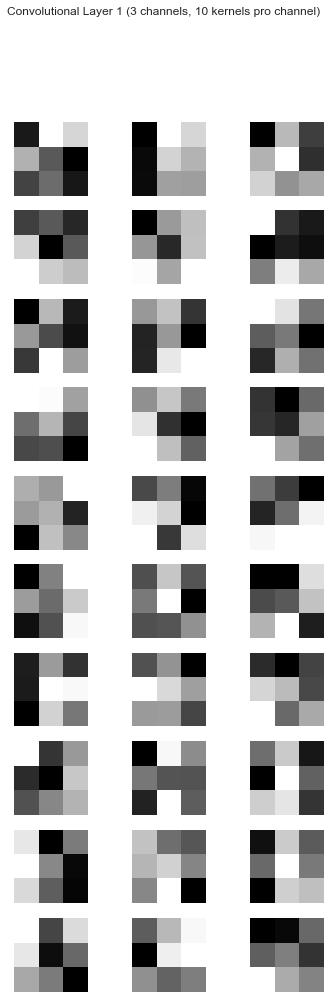

```
Conv2d(3, 32, kernel_size=(3, 3), stride=(1, 1), padding=(1, 1))
```

```python
helpers.plot_conv_kernels(cnn_model, 0, 10, "Convolutional Layer 1 (3 channels, 10 kernels pro channel)")
cnn_model.network[0].cuda()
```

[figure not shown]

```
Conv2d(32, 32, kernel_size=(3, 3), stride=(1, 1), padding=(1, 1))
```

```python
helpers.plot_conv_kernels(cnn_model, 2, 2, "Convolutional Layer 2 (3 channels, 10 kernels)")
cnn_model.network[2].cuda()
```

To show activations after convolutional layers let's take a sample image from dataset

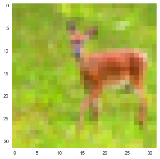

```
deer
```

```python
_images, _lables = next(iter(train_loader))
sample_img = _images[0]
sample_lable = _lables[0]

# because of normalization of dataset images have strange range, let's fix it with normalization to range [0, 1] for adequate visualization
sample_img_copy = sample_img.clone().detach()
sample_img_copy += np.abs(sample_img_copy.min())
sample_img_copy /= sample_img_copy.max()


#print(sample_img_copy.min(), sample_img_copy.max())
sns.set_style("whitegrid", {'axes.grid' : False})
plt.imshow(sample_img_copy.permute(1, 2, 0))
plt.show()
print(classes[int(sample_lable.item())])
```

We can get activations with the following hook:

```python
# a dict to store the activations
activation = {}
def getActivation(name):
      # the hook signature
    def hook(model, input, output):
        activation[name] = output.detach()
    return hook
```

```python
# lets check the structure of the model again
print(cnn_model)
```

```
CIFAR10_CNN_Classifier(
  (network): Sequential(
    (0): Conv2d(3, 32, kernel_size=(3, 3), stride=(1, 1), padding=(1, 1))
    (1): ReLU()
    (2): Conv2d(32, 32, kernel_size=(3, 3), stride=(1, 1), padding=(1, 1))
    (3): ReLU()
    (4): MaxPool2d(kernel_size=2, stride=2, padding=0, dilation=1, ceil_mode=False)
    (5): Conv2d(32, 64, kernel_size=(3, 3), stride=(1, 1), padding=(1, 1))
    (6): ReLU()
    (7): Conv2d(64, 64, kernel_size=(3, 3), stride=(1, 1), padding=(1, 1))
    (8): ReLU()
    (9): MaxPool2d(kernel_size=2, stride=2, padding=0, dilation=1, ceil_mode=False)
    (10): Flatten(start_dim=1, end_dim=-1)
    (11): Linear(in_features=4096, out_features=100, bias=True)
    (12): ReLU()
    (13): Linear(in_features=100, out_features=10, bias=True)
  )
)
```

```python
# register forward hooks on the layers of choice

h0 = cnn_model.network[1].register_forward_hook(getActivation('conv1_1'))
h1 = cnn_model.network[3].register_forward_hook(getActivation('conv1_2'))
h2 = cnn_model.network[6].register_forward_hook(getActivation('conv2_1'))
h3 = cnn_model.network[8].register_forward_hook(getActivation('conv2_2'))
```

```python
# forward pass to get predictions (don't forget about the batch dimensions)
cnn_model.forward(_images)[0]
```

```
tensor([ -2.6202, -21.5397,   6.1995,  -5.2432,  17.2928,   0.0648,  -4.8543,
        -10.3081, -13.4237, -23.1312], device='cuda:0',
       grad_fn=<SelectBackward0>)
```

```python
# sample_pred
```

```python
conv1_1_activations = activation['conv1_1'][0]
conv1_2_activations = activation['conv1_2'][0]
conv2_1_activations = activation['conv2_1'][0]
conv2_2_activations = activation['conv2_2'][0]
```

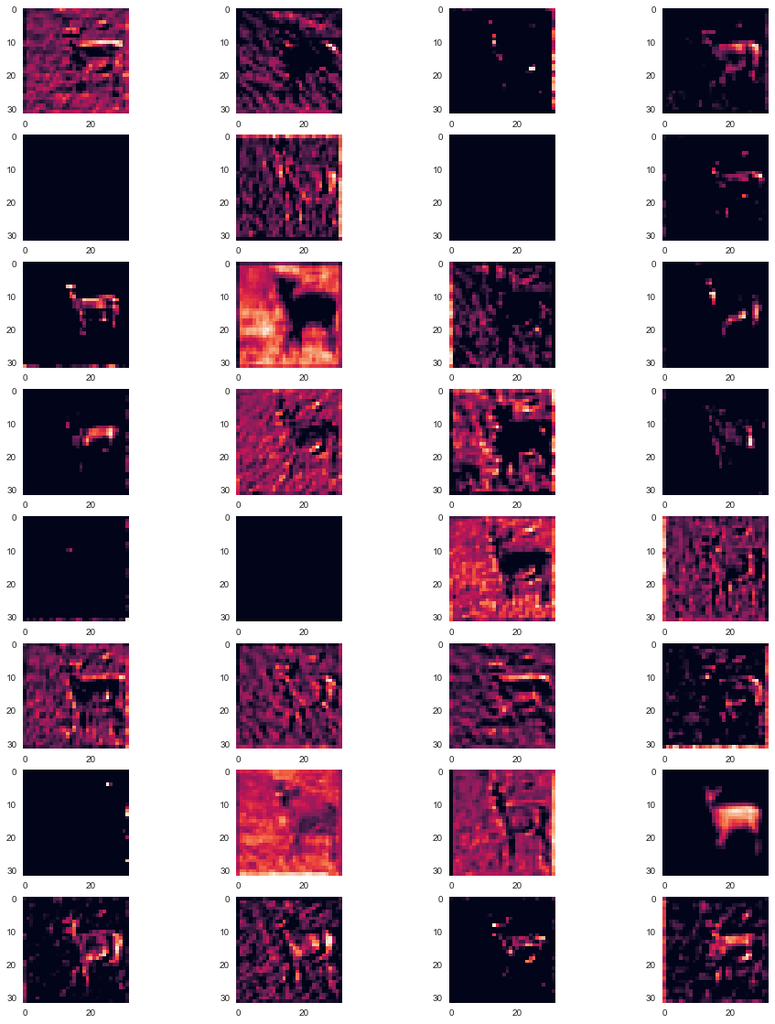

```python
fig, axs = plt.subplots(8, 4,figsize=(16,20))

for idx, act in enumerate(conv1_1_activations.cpu()):
    axs[idx%8, idx//8].imshow(act)
```

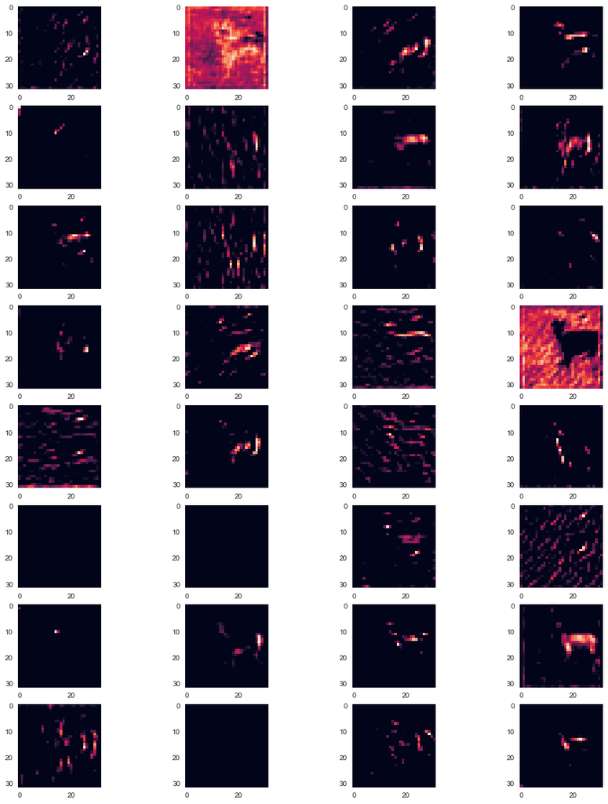

```python
fig, axs = plt.subplots(8, 4,figsize=(16,20))

for idx, act in enumerate(conv1_2_activations.cpu()):
    axs[idx%8, idx//8].imshow(act)
```

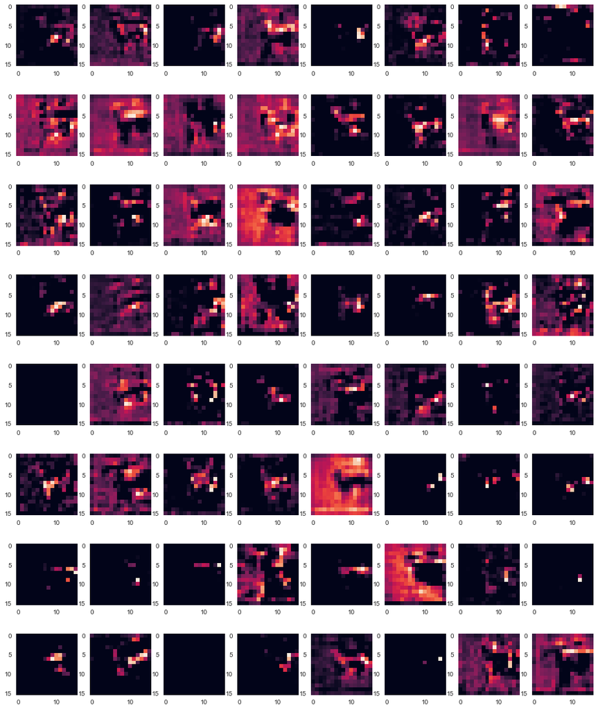

```python
fig, axs = plt.subplots(8, 8,figsize=(16,20))

for idx, act in enumerate(conv2_1_activations.cpu()):
    axs[idx%8, idx//8].imshow(act)
```

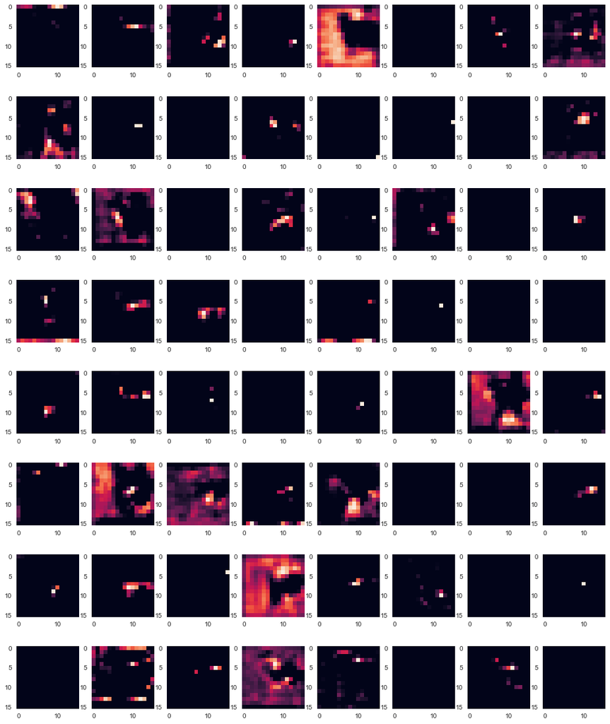

```python
fig, axs = plt.subplots(8, 8,figsize=(16,20))

for idx, act in enumerate(conv2_2_activations.cpu()):
    axs[idx%8, idx//8].imshow(act)
```

First Conv Layer extracts the overall shape of the object (in this example deer)  
Second Conv Layer extracts different kinds of lines (or other low-level features) inside the object and background  
3d and 4th Conv Layers extract more high-level features from the results of the previous layers

## Task 3.

- Train CNNs without regularization, with L2-Regularization, and with L1-Regularization. Compare the results: training and validation loss, accuracy, ...

Let's create 2 models, criterions and optimizers to test L1 and L2 regularization

```python
cnn_model_l1 = None
criterion_cnn_l1 = None
optimizer_cnn_l1 = None


cnn_model_l2 = None
criterion_cnn_l2 = None
optimizer_cnn_l2 = None
```

```python
cnn_model_l1 = CIFAR10_CNN_Classifier().to(device)
criterion_cnn_l1 = nn.CrossEntropyLoss()
optimizer_cnn_l1 = torch.optim.SGD(cnn_model_l1.parameters(), lr = 0.001, momentum=0.9)


cnn_model_l2 = CIFAR10_CNN_Classifier().to(device)
criterion_cnn_l2 = nn.CrossEntropyLoss()
optimizer_cnn_l2 = torch.optim.Adam(cnn_model_l2.parameters(), lr = LR, betas=(0.9, 0.95), weight_decay=0.0001) # L2 regularization
```

Let's train a model with L1 regularization

```python
loss_list_cnn_l1, acc_list_cnn_l1, loss_epoch_list_cnn_l1, acc_epoch_list_cnn_l1, loss_epoch_list_eval_cnn_l1, acc_epoch_list_eval_cnn_l1 = \
    trainings.train(cnn_model_l1, criterion_cnn_l1, train_loader, eval_loader,  optimizer_cnn_l1, NUM_EPOCHS, device, regularization="L1")
```

```
Test accuracy: 14.4%
```

```
Test accuracy: 19.3%
```

```
Test accuracy: 27.23%
```

```
Test accuracy: 31.31%
```

```
Test accuracy: 36.29%
```

```
Test accuracy: 41.34%
```

```
Test accuracy: 43.92%
```

```
Test accuracy: 47.33%
```

```
Test accuracy: 48.55%
```

```
Test accuracy: 49.75%
```

```
Test accuracy: 51.06%
```

```
Test accuracy: 53.02%
```

```
Test accuracy: 53.38%
```

```
Test accuracy: 55.12%
```

```
Test accuracy: 55.2%
```

```
Test accuracy: 55.95%
```

```
Test accuracy: 57.32%
```

```
Test accuracy: 57.11%
```

```
Test accuracy: 59.34%
```

```
Test accuracy: 58.75%
```

```
Test accuracy: 60.2%
```

```
Test accuracy: 60.53%
```

```
Test accuracy: 62.52%
```

```
Test accuracy: 63.29%
```

Ok, there is a significant drop in the performance in comparison with the model without regularization ;(

Let's check if the model with L1 regularization overfits

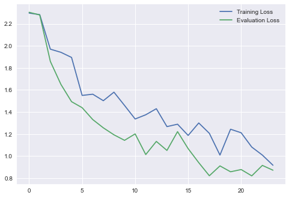

```python
plot_train_n_eval_metric(loss_epoch_list_cnn_l1, loss_epoch_list_eval_cnn_l1, mode="Loss")
```

```python
loss_list_cnn_l2, acc_list_cnn_l2, loss_epoch_list_cnn_l2, acc_epoch_list_cnn_l2, loss_epoch_list_eval_cnn_l2, acc_epoch_list_eval_cnn_l2 = \
    trainings.train(cnn_model_l2, criterion_cnn_l2, train_loader, eval_loader,  optimizer_cnn_l2, NUM_EPOCHS, device)
```

```
Test accuracy: 54.02%
```

```
Test accuracy: 62.47%
```

```
Test accuracy: 68.44%
```

```
Test accuracy: 70.55%
```

```
Test accuracy: 72.7%
```

```
Test accuracy: 72.4%
```

```
Test accuracy: 73.96%
```

```
Test accuracy: 73.36%
```

```
Test accuracy: 74.22%
```

```
Test accuracy: 74.08%
```

```
Test accuracy: 73.91%
```

```
Test accuracy: 73.15%
```

```
Test accuracy: 72.48%
```

```
Test accuracy: 73.5%
```

```
Test accuracy: 73.24%
```

```
Test accuracy: 72.72%
```

```
Test accuracy: 73.32%
```

```
Test accuracy: 72.9%
```

```
Test accuracy: 72.6%
```

```
Test accuracy: 72.46%
```

```
Test accuracy: 72.94%
```

```
Test accuracy: 72.54%
```

```
Test accuracy: 72.78%
```

```
Test accuracy: 73.45%
```

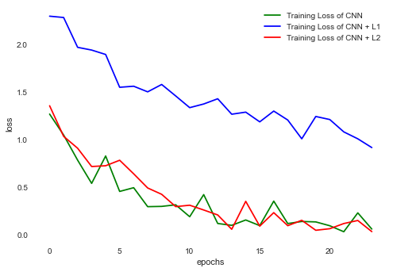

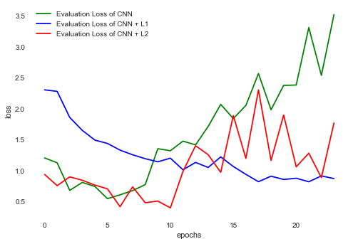

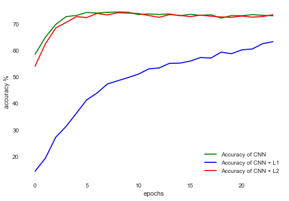

```python
plt.figure(0)
plt.plot(range(NUM_EPOCHS), loss_epoch_list_cnn, label="Training Loss of CNN", color='green')
plt.plot(range(NUM_EPOCHS), loss_epoch_list_cnn_l1, label="Training Loss of CNN + L1", color='blue')
plt.plot(range(NUM_EPOCHS), loss_epoch_list_cnn_l2, label="Training Loss of CNN + L2", color='red')

plt.xlabel('epochs')
plt.ylabel('loss')
plt.legend()

plt.figure(1)
plt.plot(range(NUM_EPOCHS), loss_epoch_list_eval_cnn, label="Evaluation Loss of CNN", color='green')
plt.plot(range(NUM_EPOCHS), loss_epoch_list_eval_cnn_l1, label="Evaluation Loss of CNN + L1", color='blue')
plt.plot(range(NUM_EPOCHS), loss_epoch_list_eval_cnn_l2, label="Evaluation Loss of CNN + L2", color='red')

plt.xlabel('epochs')
plt.ylabel('loss')
plt.legend()


plt.figure(2)
plt.plot(range(NUM_EPOCHS), acc_epoch_list_eval_cnn, label="Accuracy of CNN", color='green')
plt.plot(range(NUM_EPOCHS), acc_epoch_list_eval_cnn_l1, label="Accuracy of CNN + L1", color='blue')
plt.plot(range(NUM_EPOCHS), acc_epoch_list_eval_cnn_l2, label="Accuracy of CNN + L2", color='red')

plt.xlabel('epochs')
plt.ylabel('accuracy %')
plt.legend()

plt.show()
```

Let's check if L2 regularization prevents overfitting

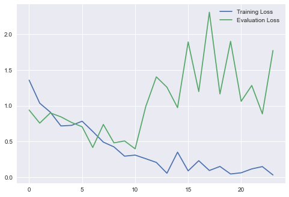

```python
plot_train_n_eval_metric(loss_epoch_list_cnn_l2, loss_epoch_list_eval_cnn_l2, mode="Loss")
```

Nope. After 10th epoch we can see significant difference between training and evaluation losses

## Task 4

- Train model with and without data augmentation. Compare the results: training and validation loss, accuracy, ...

```python
train_loader_aug, _ = dl.load_train_data("cifar10", 128, add_augmentation=True)
```

```
Files already downloaded and verified
Files already downloaded and verified
Files already downloaded and verified
```

```python
cnn_model_aug = CIFAR10_CNN_Classifier().to(device)
criterion_cnn_aug = nn.CrossEntropyLoss()
optimizer_cnn_aug = torch.optim.Adam(cnn_model_aug.parameters(), lr = LR, betas=(0.9, 0.95), weight_decay=0.0001) # L2 regularization

loss_list_cnn_aug, acc_list_cnn_aug, loss_epoch_list_cnn_aug, acc_epoch_list_cnn_aug, loss_epoch_list_eval_cnn_aug, acc_epoch_list_eval_cnn_aug = \
    trainings.train(cnn_model_aug, criterion_cnn_aug, train_loader_aug, eval_loader,  optimizer_cnn_aug, NUM_EPOCHS, device)
```

```
Test accuracy: 62.1%
```

```
Test accuracy: 70.35%
```

```
Test accuracy: 75.41%
```

```
Test accuracy: 77.2%
```

```
Test accuracy: 78.69%
```

```
Test accuracy: 79.3%
```

```
Test accuracy: 79.62%
```

```
Test accuracy: 80.63%
```

```
Test accuracy: 81.02%
```

```
Test accuracy: 79.77%
```

```
Test accuracy: 81.11%
```

```
Test accuracy: 80.95%
```

```
Test accuracy: 81.42%
```

```
Test accuracy: 80.98%
```

```
Test accuracy: 81.54%
```

```
Test accuracy: 82.32%
```

```
Test accuracy: 82.29%
```

```
Test accuracy: 82.68%
```

```
Test accuracy: 81.57%
```

```
Test accuracy: 82.02%
```

```
Test accuracy: 82.23%
```

```
Test accuracy: 82.89%
```

```
Test accuracy: 82.79%
```

```
Test accuracy: 82.57%
```

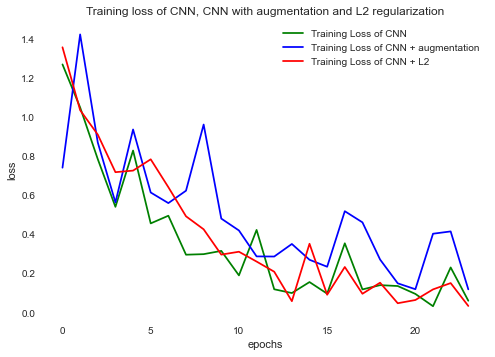

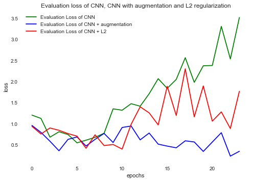

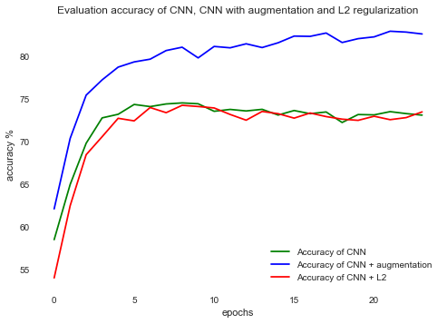

```python
plt.figure(0)
plt.plot(range(NUM_EPOCHS), loss_epoch_list_cnn, label="Training Loss of CNN", color='green')
plt.plot(range(NUM_EPOCHS), loss_epoch_list_cnn_aug, label="Training Loss of CNN + augmentation", color='blue')
plt.plot(range(NUM_EPOCHS), loss_epoch_list_cnn_l2, label="Training Loss of CNN + L2", color='red')

plt.xlabel('epochs')
plt.ylabel('loss')
plt.legend()
plt.title("Training loss of CNN, CNN with augmentation and L2 regularization")

plt.figure(1)
plt.plot(range(NUM_EPOCHS), loss_epoch_list_eval_cnn, label="Evaluation Loss of CNN", color='green')
plt.plot(range(NUM_EPOCHS), loss_epoch_list_eval_cnn_aug, label="Evaluation Loss of CNN + augmentation", color='blue')
plt.plot(range(NUM_EPOCHS), loss_epoch_list_eval_cnn_l2, label="Evaluation Loss of CNN + L2", color='red')

plt.xlabel('epochs')
plt.ylabel('loss')
plt.legend()
plt.title("Evaluation loss of CNN, CNN with augmentation and L2 regularization")


plt.figure(2)
plt.plot(range(NUM_EPOCHS), acc_epoch_list_eval_cnn, label="Accuracy of CNN", color='green')
plt.plot(range(NUM_EPOCHS), acc_epoch_list_eval_cnn_aug, label="Accuracy of CNN + augmentation", color='blue')
plt.plot(range(NUM_EPOCHS), acc_epoch_list_eval_cnn_l2, label="Accuracy of CNN + L2", color='red')

plt.xlabel('epochs')
plt.ylabel('accuracy %')
plt.legend()
plt.title("Evaluation accuracy of CNN, CNN with augmentation and L2 regularization")

plt.show()
```

The model trained on the augmented dataset performs much better than all previous models.  
Training loss is slightly higher, it's because the model does not learn dataset "by heart". As result lower evaluation loss.

Let's check if augmented dataset helps with overfitting

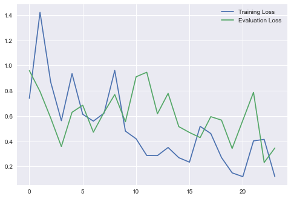

```python
plot_train_n_eval_metric(loss_epoch_list_cnn_aug, loss_epoch_list_eval_cnn_aug, mode="Loss")
```

Ok, better, but still not perfect

Now let's do the same, but this time 2 times longer (NUM_EPOCHS*2), probably it will overfit later, or something else will happend.

```python
cnn_model_aug_1 = CIFAR10_CNN_Classifier().to(device)
criterion_cnn_aug_1 = nn.CrossEntropyLoss()
optimizer_cnn_aug_1 = torch.optim.Adam(cnn_model_aug_1.parameters(), lr = LR, betas=(0.9, 0.95), weight_decay=0.0001) # L2 regularization

loss_list_cnn_aug_1, acc_list_cnn_aug_1, loss_epoch_list_cnn_aug_1, acc_epoch_list_cnn_aug_1, loss_epoch_list_eval_cnn_aug_1, acc_epoch_list_eval_cnn_aug_1 = \
    trainings.train(cnn_model_aug_1, criterion_cnn_aug_1, train_loader_aug, eval_loader,  optimizer_cnn_aug_1, NUM_EPOCHS*2, device)
```

```
Test accuracy: 58.64%
```

```
Test accuracy: 67.18%
```

```
Test accuracy: 71.91%
```

```
Test accuracy: 74.94%
```

```
Test accuracy: 75.52%
```

```
Test accuracy: 77.47%
```

```
Test accuracy: 78.14%
```

```
Test accuracy: 78.7%
```

```
Test accuracy: 79.01%
```

```
Test accuracy: 80.44%
```

```
Test accuracy: 80.02%
```

```
Test accuracy: 80.29%
```

```
Test accuracy: 81.39%
```

```
Test accuracy: 81.1%
```

```
Test accuracy: 81.09%
```

```
Test accuracy: 81.33%
```

```
Test accuracy: 80.92%
```

```
Test accuracy: 81.39%
```

```
Test accuracy: 81.78%
```

```
Test accuracy: 81.58%
```

```
Test accuracy: 81.22%
```

```
Test accuracy: 81.83%
```

```
Test accuracy: 82.08%
```

```
Test accuracy: 82.31%
```

```
Test accuracy: 82.63%
```

```
Test accuracy: 82.61%
```

```
Test accuracy: 81.88%
```

```
Test accuracy: 82.54%
```

```
Test accuracy: 81.8%
```

```
Test accuracy: 82.5%
```

```
Test accuracy: 82.61%
```

```
Test accuracy: 82.29%
```

```
Test accuracy: 81.7%
```

```
Test accuracy: 82.7%
```

```
Test accuracy: 82.94%
```

```
Test accuracy: 82.32%
```

```
Test accuracy: 82.76%
```

```
Test accuracy: 83.34%
```

```
Test accuracy: 82.27%
```

```
Test accuracy: 83.09%
```

```
Test accuracy: 83.19%
```

```
Test accuracy: 83.23%
```

```
Test accuracy: 82.37%
```

```
Test accuracy: 83.81%
```

```
Test accuracy: 83.01%
```

```
Test accuracy: 83.27%
```

```
Test accuracy: 82.92%
```

```
Test accuracy: 82.76%
```

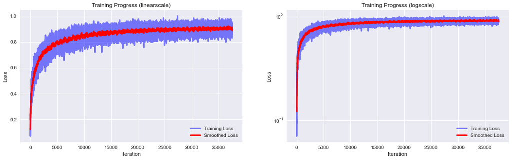

```python
helpers.plot_values_linear_n_log(acc_list_cnn_aug_1, mode="Loss")
```

Let's check if we have an overfitting

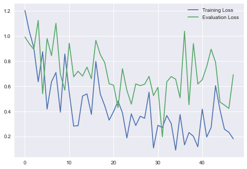

```python
plot_train_n_eval_metric(loss_epoch_list_cnn_aug_1, loss_epoch_list_eval_cnn_aug_1, mode="Loss")
```

Ok, there is still big difference between train and eval losses.  
And it seems like some overfitting after 31st epoch.  
Probably warm-up and/or schedule of learning rate will help with it. Let's check it in the next task.

## Bonus Task

I use GradualWarmupScheduler to set up the warm-up and scheduler of learning rate in the training function  
(the same function as in thaining.py + "Set up scheduler" and "Scheduler step" sections)

Let's set up warm-up for 5 first epochs. Learning rate will start from 0 and will go gradually to the defined value.  
Warm-up is chained with the StepLR-scheduler => After 5th epoch the StepLR-scheduler will start to work.  
StepLR-scheduler will reduce the learning rate every 12 epochs (it will leave only 80% from the previous value)

```python
from torch.optim.lr_scheduler import StepLR, ExponentialLR
from warmup_scheduler import GradualWarmupScheduler           # requeres pip install git+https://github.com/ildoonet/pytorch-gradual-warmup-lr.git

def train(model, criterion, train_loader, eval_loader, optimizer, epoch_num, device, regularization=None, scheduler_n_warmup=False):
    loss_list = []
    acc_list = []
    loss_epoch_list = []
    acc_epoch_list = []
    loss_epoch_list_eval = []
    acc_epoch_list_eval = []

    # ------------------------------------------ Set up scheduler ------------------------------------------
    # scheduler_warmup is chained with schduler_steplr
    if(scheduler_n_warmup):
        scheduler_steplr = StepLR(optimizer, step_size=12, gamma=0.8)
        scheduler_warmup = GradualWarmupScheduler(optimizer, multiplier=1, total_epoch=5, after_scheduler=scheduler_steplr)

        # this zero gradient update is needed to avoid a warning message, issue #8.
        optimizer.zero_grad()
        optimizer.step()
    # ------------------------------------------------------------------------------------------------------

    for epoch in range(epoch_num):
        progress_bar = tqdm(train_loader, total=len(train_loader))
        model.train()
        for i, (imgs, labels) in enumerate(progress_bar):
            # using GPU
            imgs, labels = imgs.to(device), labels.to(device)

            # forward pass
            preds = model(imgs)

            # computing error
            loss = criterion(preds, labels)
            loss_list.append(loss.item())

            if(regularization == "L1"):
                l1_lambda = 0.0001
                l1_norm = sum(torch.norm(param, 1) for param in model.parameters())

                loss = loss + l1_lambda * l1_norm
            # elif(regularization == "L2"):
            #     # "from scratch" implementation of L2 regularization, but pytorch has it built in as weight_decay parameter in the optimizer
            #     l2_lambda = 0.001
            #     l2_norm = sum(p.pow(2.0).sum()
            #                     for p in model.parameters())

            #     loss = loss + l2_lambda * l2_norm

            # computing accuracy
            train_acc = (preds.argmax(dim=1) == labels).float().mean()
            acc_list.append(train_acc.item())

            # removing accumulated gradients
            optimizer.zero_grad()

            # backprogating error to compute gradients
            loss.backward()

            # updating arameters
            optimizer.step()

            if(i % 100 == 0 or i == len(train_loader) - 1):
                progress_bar.set_description(f"Epoch {epoch + 1} Iter {i + 1}: loss {loss.item():.5f}. ")
        loss_epoch_list.append(loss_list[-1])
        acc_epoch_list.append(acc_list[-1])


        # evaluating on validation set
        model.eval()
        temp_accuracy, temp_y_true, temp_y_pred, temp_eval_loss_list = evaluations.evaluate_model(model, criterion, eval_loader, device)
        loss_epoch_list_eval.append(temp_eval_loss_list[-1])
        acc_epoch_list_eval.append(temp_accuracy)
        # ----------------------------------------- Scheduler step -----------------------------------------
        if(scheduler_n_warmup):
            scheduler_warmup.step(epoch)
        # --------------------------------------------------------------------------------------------------

    return loss_list, acc_list, loss_epoch_list, acc_epoch_list, loss_epoch_list_eval, acc_epoch_list_eval
```

Let's train the model on the augmented dataset (same hyperparameters as last time)

```python
cnn_model_aug_2 = CIFAR10_CNN_Classifier().to(device)
criterion_cnn_aug_2 = nn.CrossEntropyLoss()
optimizer_cnn_aug_2 = torch.optim.Adam(cnn_model_aug_2.parameters(), lr = LR, betas=(0.9, 0.95), weight_decay=0.0001) # L2 regularization

loss_list_cnn_aug_2, acc_list_cnn_aug_2, loss_epoch_list_cnn_aug_2, acc_epoch_list_cnn_aug_2, loss_epoch_list_eval_cnn_aug_2, acc_epoch_list_eval_cnn_aug_2 = \
    train(cnn_model_aug_2, criterion_cnn_aug_2, train_loader_aug, eval_loader,  optimizer_cnn_aug_2, NUM_EPOCHS*2, device, scheduler_n_warmup=True)
```

```
Test accuracy: 11.24%
```

```
Test accuracy: 11.24%
```

```
Test accuracy: 47.71%
```

```
Test accuracy: 58.29%
```

```
Test accuracy: 66.79%
```

```
Test accuracy: 72.11%
```

```
Test accuracy: 76.32%
```

```
Test accuracy: 78.08%
```

```
Test accuracy: 79.27%
```

```
Test accuracy: 80.16%
```

```
Test accuracy: 78.69%
```

```
Test accuracy: 81.34%
```

```
Test accuracy: 81.56%
```

```
Test accuracy: 81.76%
```

```
Test accuracy: 81.53%
```

```
Test accuracy: 82.35%
```

```
Test accuracy: 82.85%
```

```
Test accuracy: 82.9%
```

```
Test accuracy: 82.3%
```

```
Test accuracy: 83.05%
```

```
Test accuracy: 83.12%
```

```
Test accuracy: 83.06%
```

```
Test accuracy: 83.42%
```

```
Test accuracy: 83.07%
```

```
Test accuracy: 83.77%
```

```
Test accuracy: 84.0%
```

```
Test accuracy: 82.65%
```

```
Test accuracy: 83.57%
```

```
Test accuracy: 83.72%
```

```
Test accuracy: 84.38%
```

```
Test accuracy: 84.62%
```

```
Test accuracy: 84.5%
```

```
Test accuracy: 83.9%
```

```
Test accuracy: 84.62%
```

```
Test accuracy: 84.83%
```

```
Test accuracy: 84.61%
```

```
Test accuracy: 84.6%
```

```
Test accuracy: 85.1%
```

```
Test accuracy: 84.47%
```

```
Test accuracy: 85.26%
```

```
Test accuracy: 84.83%
```

```
Test accuracy: 84.66%
```

```
Test accuracy: 85.27%
```

```
Test accuracy: 85.11%
```

```
Test accuracy: 85.26%
```

```
Test accuracy: 85.08%
```

```
Test accuracy: 85.48%
```

```
Test accuracy: 85.0%
```

Let's check the training and evaluation losses

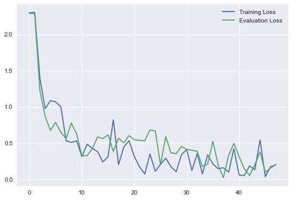

```python
plot_train_n_eval_metric(loss_epoch_list_cnn_aug_2, loss_epoch_list_eval_cnn_aug_2, mode="Loss")
```

Nice.  
Training loss and evaluation loss are very close to each other and there is an improvement  
of accuracy about 2% in comparison with the training without learning rate warm-up and scheduler